# R Notebook

## Project 1: A “data story” on the history of philosophy

*Project Description*

This is the first and only individual (as opposed to team) project this semester.

Term: Spring 2022

Projec title: Based on the philosophy belief, how does people feel about the world?

This project is conducted by Yixuan Zhang

Project summary: [a short summary] As a human being, we may often ask ourselves the question – “What kind of person am I?” Throughout our lives, we may always on the way to learn more about ourselves and others. However, the belief is intangible and unmeasurable, but with the help of modern data analysis tools, we may form some ideas to the former question by conducting experiements forcusing on people’s sentiments and emotions. In this project, I will use the data from The Philosophy Data Project (http://philosophydata.com/index.html), which contains 51 philosophical texts spanning 13 core schools of philosophy, including Rationalism, Empiricism, Capitalism, etc. My goal is to see what sentiments and emotions are people tend to have in each school of philosophy. Hopefully, it can help us understand the core beliefs of people in the modern era including ourselves.

Project outline: My whole project contains four steps, including

Step0: Install and load lobraries;

Step 1: Read in data and processing;

Step 2: Data analysis: The highlight of this project;

Step 3: Visualizations.

# Step 0 - Install and load libraries

```r
packages.used=c("readr","sentimentr","tm", "dplyr", "tydytext","pheatmap")
# check packages that need to be installed.
packages.needed=setdiff(packages.used,
                        intersect(installed.packages()[,1],
                                  packages.used))
# install additional packages
#if(length(packages.needed)>0){
#  install.packages(packages.needed, dependencies = TRUE)
#}
library(readr)
library(tm)
library(dplyr)
library(sentimentr)
library(tidytext)
library(syuzhet)
library(pheatmap)
```

# Step 1: read in data and data Processing

```r
df<-read_csv("/Users/apple/Desktop/philosophy_data.csv")[,1:11]
```

The raw data is very tidy, which contains all the information I need so I do not need to create a new column myself. The columns I used in this project is “school” and “sentence_lowered”. The “school” column indicates which school of philosophy is the line of data belongs to. The “sentence_lowered” column contains the sentence we want with lower-case. The reason that I use these sentences rather than the sentences with capital letters is that the package I used may have difficulties identify the word with upper-case, which as a result decrease my output accuracy.

```r
school_list<-unique(df[["school"]])
word_list<-df[["tokenized_txt"]]
sentence<-df[["sentence_lowered"]]
```

# Step 2: Data analysis — sentiment analsis

Considering the computer power consumption, I randomly sample the raw data into a new dataset which contains 3000 line of data (about 1% of the raw data). If computer condition permits, you can change into the raw data, which would produce a more accurate result.

```r
index = sample(1:nrow(df),3000)
```

```r
emotions = get_nrc_sentiment(sentence[index])
write.csv(emotions,"/Users/apple/Downloads/spring-2022-prj1-codingellena/output/emotions.csv")
df_emotions = cbind(df[index,],emotions)
write.csv(df_emotions,"/Users/apple/Downloads/spring-2022-prj1-codingellena/output/df_emotions.csv")
```

```r
emotions_school =  data.frame(matrix(NA, ncol=10, nrow = 13))
colnames(emotions_school) = colnames(emotions)
rownames(emotions_school) = school_list
for (i in 1:length(school_list)){
  for(j in 1:length(colnames(emotions))){
    emotions_school[i,j] = round(mean(df_emotions[which(df_emotions$school==school_list[i]),colnames(emotions)[j]]),2)
    }
}
emotions_school
```

```
##                 anger anticipation disgust fear  joy sadness surprise trust
## plato            0.31         0.44    0.17 0.35 0.40    0.27     0.26  0.67
## aristotle        0.32         0.47    0.27 0.44 0.44    0.35     0.19  0.70
## empiricism       0.37         0.61    0.19 0.55 0.49    0.38     0.25  1.05
## rationalism      0.35         0.65    0.22 0.44 0.58    0.30     0.22  0.97
## analytic         0.16         0.34    0.08 0.23 0.11    0.21     0.11  0.59
## continental      0.47         0.55    0.27 0.67 0.31    0.55     0.24  0.91
## phenomenology    0.17         0.45    0.10 0.31 0.24    0.19     0.14  0.70
## german_idealism  0.26         0.45    0.12 0.35 0.32    0.27     0.15  1.06
## communism        0.36         0.49    0.14 0.40 0.26    0.39     0.21  0.66
## capitalism       0.29         0.70    0.14 0.27 0.61    0.34     0.31  1.07
## stoicism         0.26         0.95    0.26 0.63 0.68    0.63     0.32  1.16
## nietzsche        0.32         0.57    0.33 0.49 0.56    0.42     0.32  0.90
## feminism         0.41         0.84    0.32 0.49 0.82    0.52     0.28  1.15
##                 negative positive
## plato               0.60     0.99
## aristotle           0.78     1.15
## empiricism          0.96     1.72
## rationalism         0.74     1.53
## analytic            0.43     0.81
## continental         1.09     1.50
## phenomenology       0.57     1.31
## german_idealism     0.65     1.75
## communism           0.86     1.16
## capitalism          0.75     1.91
## stoicism            1.21     1.68
## nietzsche           0.92     1.26
## feminism            1.00     1.86
```

```r
write.csv(emotions_school,"/Users/apple/Downloads/spring-2022-prj1-codingellena/output/emotions_school.csv")
```

*Analysis*

Since the matrix cannot give us an intuitive idea of the result, I draw a heatmap to visualize it.

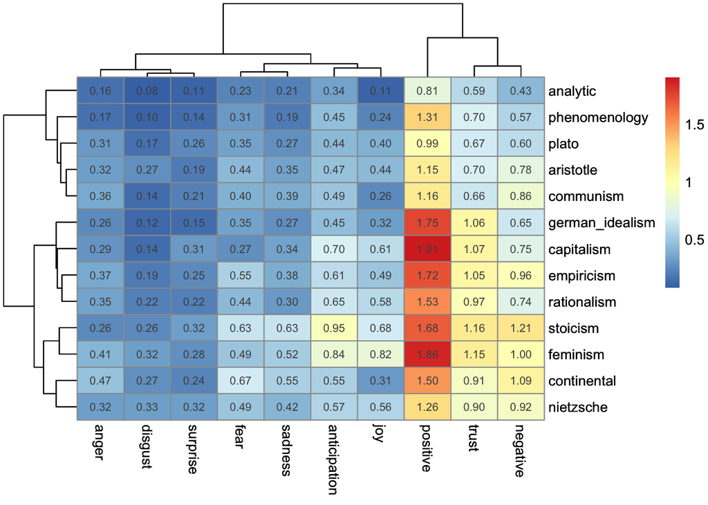

```r
#heatmap
x<-as.matrix(emotions_school)
pdf("/Users/apple/Downloads/spring-2022-prj1-codingellena/figs/heatmap.pdf")
heatplot<-pheatmap(x, display_numbers = T)
print(heatplot)
```

```r
dev.off()
```

In the heatmap above, the cell with red color indicates that the category the cell represents wins a higher score; the cell with blue color indicates that the category the cell represents wins a lower score.